```python
# LIBRARIES


import time


import pandas as pd
import numpy as np
import seaborn as sns
from sklearn.preprocessing import StandardScaler
from matplotlib import pyplot

import matplotlib.pyplot as plt
from sklearn.preprocessing import LabelEncoder
from sklearn.decomposition import PCA
from sklearn.cross_validation import cross_val_score
from sklearn import metrics
from sklearn.svm import SVC
from sklearn.model_selection import train_test_split
from sklearn.grid_search import GridSearchCV
from sklearn.metrics import roc_curve, auc




pd.set_option('display.max_columns', None)
pd.set_option('display.expand_frame_repr', False)
pd.set_option('max_colwidth', -1)
#%%
```

# DATASET

about this Dataset

Voice Gender Gender Recognition by Voice and Speech Analysis

This database was created to identify a voice as male or female, based upon acoustic properties of the voice and speech. The dataset consists of 3,168 recorded voice samples, collected from male and female speakers. The voice samples are pre-processed by acoustic analysis in R using the seewave and tuneR packages, with an analyzed frequency range of 0hz-280hz (human vocal range).

The Dataset The following acoustic properties of each voice are measured and included within the CSV:

meanfreq: mean frequency (in kHz) sd: standard deviation of frequency median: median frequency (in kHz) Q25: first quantile (in kHz) Q75: third quantile (in kHz) IQR: interquantile range (in kHz) skew: skewness (see note in specprop description) kurt: kurtosis (see note in specprop description) sp.ent: spectral entropy sfm: spectral flatness mode: mode frequency centroid: frequency centroid (see specprop) peakf: peak frequency (frequency with highest energy) meanfun: average of fundamental frequency measured across acoustic signal minfun: minimum fundamental frequency measured across acoustic signal maxfun: maximum fundamental frequency measured across acoustic signal meandom: average of dominant frequency measured across acoustic signal mindom: minimum of dominant frequency measured across acoustic signal maxdom: maximum of dominant frequency measured across acoustic signal dfrange: range of dominant frequency measured across acoustic signal modindx: modulation index. Calculated as the accumulated absolute difference between adjacent measurements of fundamental frequencies divided by the frequency range label: male or female

Voice samples were collected from the following resources:

The Harvard-Haskins Database of Regularly-Timed Speech Telecommunications & Signal Processing Laboratory (TSP) Speech Database at McGill University VoxForge Speech CorpusDesktop Festvox CMU_ARCTIC Speech Database at Carnegie Mellon University

source: https://data.world/ml-research/gender-recognition-by-voice

```python
df = pd.read_csv('/Users/dv/Desktop/CloudStation/2018_MCSBT/02_Term/ML_AI/Individual/CSV/voice_dataset.csv')
```

Decision to choose this dataset for the SVM Assignment

```python
# The main reason to choose this data set is that it is perfect to practice an excercise of classification base on a binary
# either the voice is male or female. At the same time is back up by univeristies such as Harvard or Carnegie Mellon
# one can feel comfortable about the veracity and usefulness of it

# RAW DATA
%time
df.head()
```

```
CPU times: user 2 µs, sys: 0 ns, total: 2 µs
Wall time: 5.96 µs
```

|  | meanfreq | sd | median | Q25 | Q75 | IQR | skew | kurt | sp.ent | sfm | mode | centroid | meanfun | minfun | maxfun | meandom | mindom | maxdom | dfrange | modindx | label |
| --- | --- | --- | --- | --- | --- | --- | --- | --- | --- | --- | --- | --- | --- | --- | --- | --- | --- | --- | --- | --- | --- |
| 0 | 0.059781 | 0.064241 | 0.032027 | 0.015071 | 0.090193 | 0.075122 | 12.863462 | 274.402906 | 0.893369 | 0.491918 | 0.000000 | 0.059781 | 0.084279 | 0.015702 | 0.275862 | 0.007812 | 0.007812 | 0.007812 | 0.000000 | 0.000000 | male |
| 1 | 0.066009 | 0.067310 | 0.040229 | 0.019414 | 0.092666 | 0.073252 | 22.423285 | 634.613855 | 0.892193 | 0.513724 | 0.000000 | 0.066009 | 0.107937 | 0.015826 | 0.250000 | 0.009014 | 0.007812 | 0.054688 | 0.046875 | 0.052632 | male |
| 2 | 0.077316 | 0.083829 | 0.036718 | 0.008701 | 0.131908 | 0.123207 | 30.757155 | 1024.927705 | 0.846389 | 0.478905 | 0.000000 | 0.077316 | 0.098706 | 0.015656 | 0.271186 | 0.007990 | 0.007812 | 0.015625 | 0.007812 | 0.046512 | male |
| 3 | 0.151228 | 0.072111 | 0.158011 | 0.096582 | 0.207955 | 0.111374 | 1.232831 | 4.177296 | 0.963322 | 0.727232 | 0.083878 | 0.151228 | 0.088965 | 0.017798 | 0.250000 | 0.201497 | 0.007812 | 0.562500 | 0.554688 | 0.247119 | male |
| 4 | 0.135120 | 0.079146 | 0.124656 | 0.078720 | 0.206045 | 0.127325 | 1.101174 | 4.333713 | 0.971955 | 0.783568 | 0.104261 | 0.135120 | 0.106398 | 0.016931 | 0.266667 | 0.712812 | 0.007812 | 5.484375 | 5.476562 | 0.208274 | male |

```python
df.info()
```

```
<class 'pandas.core.frame.DataFrame'>
RangeIndex: 3168 entries, 0 to 3167
Data columns (total 21 columns):
meanfreq    3168 non-null float64
sd          3168 non-null float64
median      3168 non-null float64
Q25         3168 non-null float64
Q75         3168 non-null float64
IQR         3168 non-null float64
skew        3168 non-null float64
kurt        3168 non-null float64
sp.ent      3168 non-null float64
sfm         3168 non-null float64
mode        3168 non-null float64
centroid    3168 non-null float64
meanfun     3168 non-null float64
minfun      3168 non-null float64
maxfun      3168 non-null float64
meandom     3168 non-null float64
mindom      3168 non-null float64
maxdom      3168 non-null float64
dfrange     3168 non-null float64
modindx     3168 non-null float64
label       3168 non-null object
dtypes: float64(20), object(1)
memory usage: 519.8+ KB
```

```python
df.shape
```

```
(3168, 21)
```

```python
# CHECKING NULL VALUES
df.isnull().sum()
```

```
meanfreq    0
sd          0
median      0
Q25         0
Q75         0
IQR         0
skew        0
kurt        0
sp.ent      0
sfm         0
mode        0
centroid    0
meanfun     0
minfun      0
maxfun      0
meandom     0
mindom      0
maxdom      0
dfrange     0
modindx     0
label       0
dtype: int64
```

All the features and numerical and there is no null values. This means that this dataset is perfect for clasification since we do not have to encode string variables either to fill null values. This would allow to focus on the study of SVM by itself. In any case, we need to encode the feature "label".

```python
# Hotencoding Gender Feature and droping "label" that contains strings
gender=df.iloc[:,-1]
gender_encoder = LabelEncoder()
gender = gender_encoder.fit_transform(gender)
df['gender'] = gender
df = df.drop(['label'], axis=1)
df.head()
```

|  | meanfreq | sd | median | Q25 | Q75 | IQR | skew | kurt | sp.ent | sfm | mode | centroid | meanfun | minfun | maxfun | meandom | mindom | maxdom | dfrange | modindx | gender |
| --- | --- | --- | --- | --- | --- | --- | --- | --- | --- | --- | --- | --- | --- | --- | --- | --- | --- | --- | --- | --- | --- |
| 0 | 0.059781 | 0.064241 | 0.032027 | 0.015071 | 0.090193 | 0.075122 | 12.863462 | 274.402906 | 0.893369 | 0.491918 | 0.000000 | 0.059781 | 0.084279 | 0.015702 | 0.275862 | 0.007812 | 0.007812 | 0.007812 | 0.000000 | 0.000000 | 1 |
| 1 | 0.066009 | 0.067310 | 0.040229 | 0.019414 | 0.092666 | 0.073252 | 22.423285 | 634.613855 | 0.892193 | 0.513724 | 0.000000 | 0.066009 | 0.107937 | 0.015826 | 0.250000 | 0.009014 | 0.007812 | 0.054688 | 0.046875 | 0.052632 | 1 |
| 2 | 0.077316 | 0.083829 | 0.036718 | 0.008701 | 0.131908 | 0.123207 | 30.757155 | 1024.927705 | 0.846389 | 0.478905 | 0.000000 | 0.077316 | 0.098706 | 0.015656 | 0.271186 | 0.007990 | 0.007812 | 0.015625 | 0.007812 | 0.046512 | 1 |
| 3 | 0.151228 | 0.072111 | 0.158011 | 0.096582 | 0.207955 | 0.111374 | 1.232831 | 4.177296 | 0.963322 | 0.727232 | 0.083878 | 0.151228 | 0.088965 | 0.017798 | 0.250000 | 0.201497 | 0.007812 | 0.562500 | 0.554688 | 0.247119 | 1 |
| 4 | 0.135120 | 0.079146 | 0.124656 | 0.078720 | 0.206045 | 0.127325 | 1.101174 | 4.333713 | 0.971955 | 0.783568 | 0.104261 | 0.135120 | 0.106398 | 0.016931 | 0.266667 | 0.712812 | 0.007812 | 5.484375 | 5.476562 | 0.208274 | 1 |

# EXPLORATION

```python
df.describe()
```

|  | meanfreq | sd | median | Q25 | Q75 | IQR | skew | kurt | sp.ent | sfm | mode | centroid | meanfun | minfun | maxfun | meandom | mindom | maxdom | dfrange | modindx | gender |
| --- | --- | --- | --- | --- | --- | --- | --- | --- | --- | --- | --- | --- | --- | --- | --- | --- | --- | --- | --- | --- | --- |
| count | 3168.000000 | 3168.000000 | 3168.000000 | 3168.000000 | 3168.000000 | 3168.000000 | 3168.000000 | 3168.000000 | 3168.000000 | 3168.000000 | 3168.000000 | 3168.000000 | 3168.000000 | 3168.000000 | 3168.000000 | 3168.000000 | 3168.000000 | 3168.000000 | 3168.000000 | 3168.000000 | 3168.000000 |
| mean | 0.180907 | 0.057126 | 0.185621 | 0.140456 | 0.224765 | 0.084309 | 3.140168 | 36.568461 | 0.895127 | 0.408216 | 0.165282 | 0.180907 | 0.142807 | 0.036802 | 0.258842 | 0.829211 | 0.052647 | 5.047277 | 4.994630 | 0.173752 | 0.500000 |
| std | 0.029918 | 0.016652 | 0.036360 | 0.048680 | 0.023639 | 0.042783 | 4.240529 | 134.928661 | 0.044980 | 0.177521 | 0.077203 | 0.029918 | 0.032304 | 0.019220 | 0.030077 | 0.525205 | 0.063299 | 3.521157 | 3.520039 | 0.119454 | 0.500079 |
| min | 0.039363 | 0.018363 | 0.010975 | 0.000229 | 0.042946 | 0.014558 | 0.141735 | 2.068455 | 0.738651 | 0.036876 | 0.000000 | 0.039363 | 0.055565 | 0.009775 | 0.103093 | 0.007812 | 0.004883 | 0.007812 | 0.000000 | 0.000000 | 0.000000 |
| 25% | 0.163662 | 0.041954 | 0.169593 | 0.111087 | 0.208747 | 0.042560 | 1.649569 | 5.669547 | 0.861811 | 0.258041 | 0.118016 | 0.163662 | 0.116998 | 0.018223 | 0.253968 | 0.419828 | 0.007812 | 2.070312 | 2.044922 | 0.099766 | 0.000000 |
| 50% | 0.184838 | 0.059155 | 0.190032 | 0.140286 | 0.225684 | 0.094280 | 2.197101 | 8.318463 | 0.901767 | 0.396335 | 0.186599 | 0.184838 | 0.140519 | 0.046110 | 0.271186 | 0.765795 | 0.023438 | 4.992188 | 4.945312 | 0.139357 | 0.500000 |
| 75% | 0.199146 | 0.067020 | 0.210618 | 0.175939 | 0.243660 | 0.114175 | 2.931694 | 13.648905 | 0.928713 | 0.533676 | 0.221104 | 0.199146 | 0.169581 | 0.047904 | 0.277457 | 1.177166 | 0.070312 | 7.007812 | 6.992188 | 0.209183 | 1.000000 |
| max | 0.251124 | 0.115273 | 0.261224 | 0.247347 | 0.273469 | 0.252225 | 34.725453 | 1309.612887 | 0.981997 | 0.842936 | 0.280000 | 0.251124 | 0.237636 | 0.204082 | 0.279114 | 2.957682 | 0.458984 | 21.867188 | 21.843750 | 0.932374 | 1.000000 |

```
CPU times: user 3 µs, sys: 1 µs, total: 4 µs
Wall time: 9.06 µs
```

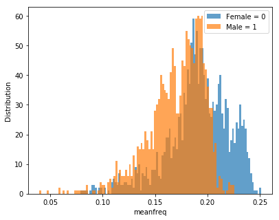

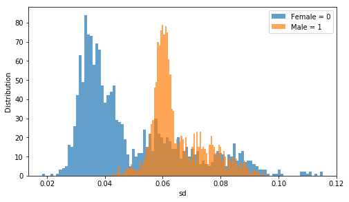

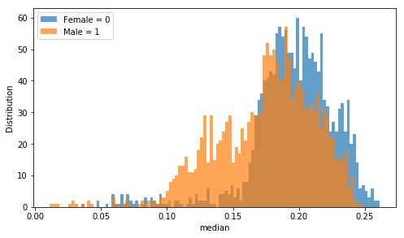

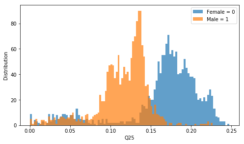

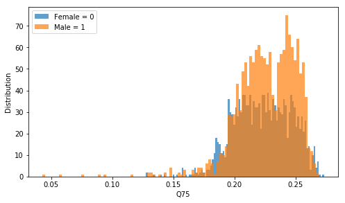

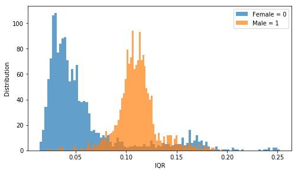

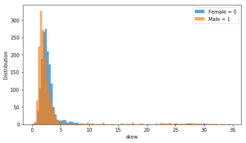

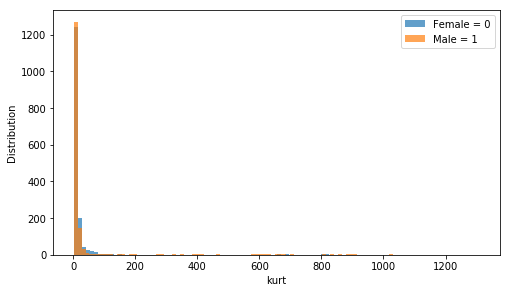

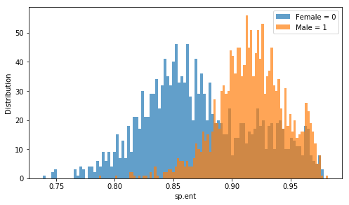

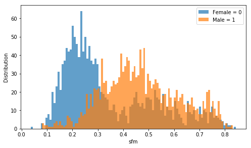

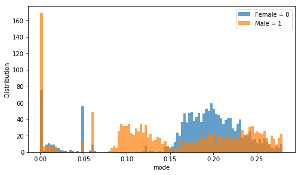

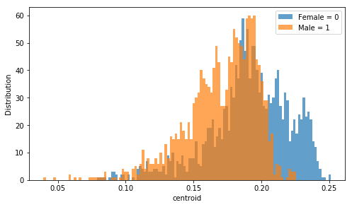

[9 more figures not shown]

```python
#Histogram plots for visualizing how each feature would help us to difer if it is female or male
%time

plt.figure(figsize=(14,5))
#bins = np.linspace(-.1,.1)



plt.subplot(1,2,1)
count = 0
for key in df.keys():
    if key != 'gender':
        plt.hist(df[key][df['gender'] == 0], bins=100, alpha = 0.7, label = 'Female = 0')
        plt.hist(df[key][df['gender'] == 1], bins=100, alpha = 0.7, label = 'Male = 1')
        plt.ylabel('Distribution')
        plt.xlabel(key)
        plt.legend()
        plt.show()
```

From this histograms we can see that sd, Q25, IQR, sp.ent and meanfun are the main fetures that would help to identify the gender.

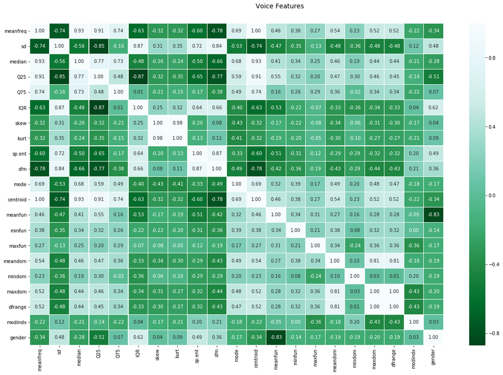

```python
#Checking the correlation between each features


f, ax = plt.subplots(figsize=(20, 12))
corr = df.corr()
hm = sns.heatmap(round(corr,2), annot=True, ax=ax, cmap="BuGn_r",fmt='.2f',
                 linewidths=.05)
f.subplots_adjust(top=0.93)
t= f.suptitle('Voice Features', fontsize=14)
```

There are several features very correlated, either directly or inversely. This could give us a hint that it would be needed to do PCA or some dimension reduction in order to improve the model accuracy and timing performance. And as we predictided while checking the histograms, meanfun place an important role because of the correlation that is shown with gender.

# Separating Features and Standarisation

```python
X=df.iloc[:, :-1]
y=df.iloc[:,-1]

scaler = StandardScaler()
scaler.fit(X)
X = scaler.transform(X)
print(X.shape)
print(y.shape)
# Standardization refers to shifting the distribution of each attribute to have a mean of zero and a standard deviation
#of one (unit variance). This way we guarantee that the units of measurments are not giving more or less weight to any
#of the features.
```

```
(3168, 20)
(3168,)
```

# SPLIT DATASET

We will a division 70% train and 30% test

```python
X_train, X_test, y_train, y_test = train_test_split(X, y, test_size=0.3, random_state=1)
```

# RUNNING SVM | Default Parameters

From the package offered by scikitlearn for SVM, we are going to use the SVC (Supported Vector Classification) since " The fit time complexity is more than quadratic with the number of samples which makes it hard to scale to dataset with more than a couple of 10000 samples."

source: https://scikit-learn.org/stable/modules/generated/sklearn.svm.SVC.html#sklearn.svm.SVC

In order to have a first approach, we are going to run the three kernels,

1. RBF (Radius Basic Functions)
2. Linear
3. Polynomial

```python
#1. RBF

svc=SVC(kernel='rbf')
svc.fit(X_train,y_train)
y_pred=svc.predict(X_test)
print('Accuracy Score SVM before Cross Validation and RBF Kernel:')
print(metrics.accuracy_score(y_test,y_pred))

confusion_matrix=metrics.confusion_matrix(y_test,y_pred)
print (confusion_matrix)
```

```
Accuracy Score SVM before Cross Validation and RBF Kernel:
0.9810725552050473
[[451   6]
 [ 12 482]]
```

```python
svc=SVC(kernel='linear')
svc.fit(X_train,y_train)
y_pred=svc.predict(X_test)
print('Accuracy Score SVM before Cross Validation and Linear:')
print(metrics.accuracy_score(y_test,y_pred))

confusion_matrix=metrics.confusion_matrix(y_test,y_pred)
print (confusion_matrix)
```

```
Accuracy Score SVM before Cross Validation and Linear:
0.9768664563617245
[[448   9]
 [ 13 481]]
```

```python
svc=SVC(kernel='poly')
svc.fit(X_train,y_train)
y_pred=svc.predict(X_test)
print('Accuracy Score SVM before Cross Validation and Polynomial Kernel:')
print(metrics.accuracy_score(y_test,y_pred))

confusion_matrix=metrics.confusion_matrix(y_test,y_pred)
print (confusion_matrix)
```

```
Accuracy Score SVM before Cross Validation and Polynomial Kernel:
0.9600420609884333
[[427  30]
 [  8 486]]
```

As a first conclusion the best model is RBF and the worst one Polynomial but the high values of accuracy could mean that we are overfitting. In oreder to avoide it, we need to "shuffle" the dataset when choosing test and test data points. For this matter we will use Cross Validation.

# RUNNING SVM | Default Parameters

Now we will try to find out what is the best performance with these paramaters to find a number of cross validation.

```
Mean Accuracy Kernel RBF and Cross Validation:
0.9169823232323233
Mean Accuracy Kernel RBF and Cross Validation:
0.9599116161616162
Mean Accuracy Kernel RBF and Cross Validation:
0.9652777777777778
Mean Accuracy Kernel RBF and Cross Validation:
0.9677963902088408
Mean Accuracy Kernel RBF and Cross Validation:
0.9674873737373737
Mean Accuracy Kernel RBF and Cross Validation:
0.9665579732341262
Mean Accuracy Kernel RBF and Cross Validation:
0.9715909090909091
Mean Accuracy Kernel RBF and Cross Validation:
0.9709595959595959
Mean Accuracy Kernel RBF and Cross Validation:
0.9659382214791815
Mean Accuracy Kernel RBF and Cross Validation:
0.9665404040404041
```

```
Text(0,0.5,'Cross-Validated Accuracy')
```

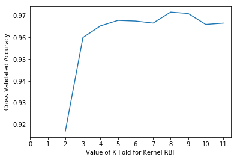

```python
#1. RBF
cv = list(range(2,12))
cross_validation_score = []

for i in cv:
    svc=SVC(kernel='rbf')
    svc.fit(X_train,y_train)
    y_pred=svc.predict(X_test)
    scores = cross_val_score(svc, X, y, cv=i, scoring='accuracy')
    print('Mean Accuracy Kernel RBF and Cross Validation:')
    print(scores.mean())
    cross_validation_score.append(scores.mean())

plt.plot(cv,cross_validation_score)
plt.xticks(np.arange(0,12,1))
plt.xlabel('Value of K-Fold for Kernel RBF')
plt.ylabel('Cross-Validated Accuracy')
```

To be conversvative and be aware not being overfitting, we select 7 as the perfect number of CV

```
Mean Accuracy Kernel RBF and Cross Validation:
0.9472853535353536
Mean Accuracy Kernel RBF and Cross Validation:
0.9618055555555557
Mean Accuracy Kernel RBF and Cross Validation:
0.9671717171717171
Mean Accuracy Kernel RBF and Cross Validation:
0.9671754582118754
Mean Accuracy Kernel RBF and Cross Validation:
0.9690656565656566
Mean Accuracy Kernel RBF and Cross Validation:
0.9675131016891572
Mean Accuracy Kernel RBF and Cross Validation:
0.96875
Mean Accuracy Kernel RBF and Cross Validation:
0.9690656565656567
Mean Accuracy Kernel RBF and Cross Validation:
0.9694132632752168
Mean Accuracy Kernel RBF and Cross Validation:
0.9681186868686869
```

```
Text(0,0.5,'Cross-Validated Accuracy')
```

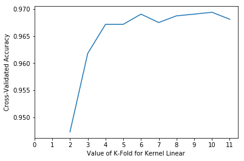

```python
#2. Linear
cv = list(range(2,12))
cross_validation_score = []

for i in cv:
    svc=SVC(kernel='linear')
    svc.fit(X_train,y_train)
    y_pred=svc.predict(X_test)
    scores = cross_val_score(svc, X, y, cv=i, scoring='accuracy')
    print('Mean Accuracy Kernel RBF and Cross Validation:')
    print(scores.mean())
    cross_validation_score.append(scores.mean())

plt.plot(cv,cross_validation_score)
plt.xticks(np.arange(0,12,1))
plt.xlabel('Value of K-Fold for Kernel Linear')
plt.ylabel('Cross-Validated Accuracy')
```

To be conversvative and be aware not being overfitting, we select 7 as the perfect number of CV

```
Mean Accuracy Kernel RBF and Cross Validation:
0.8993055555555556
Mean Accuracy Kernel RBF and Cross Validation:
0.9157196969696969
Mean Accuracy Kernel RBF and Cross Validation:
0.9397095959595959
Mean Accuracy Kernel RBF and Cross Validation:
0.9393852573573455
Mean Accuracy Kernel RBF and Cross Validation:
0.9381313131313131
Mean Accuracy Kernel RBF and Cross Validation:
0.9425725535623786
Mean Accuracy Kernel RBF and Cross Validation:
0.9491792929292929
Mean Accuracy Kernel RBF and Cross Validation:
0.9494949494949494
Mean Accuracy Kernel RBF and Cross Validation:
0.9457646684181196
Mean Accuracy Kernel RBF and Cross Validation:
0.9422348484848485
```

```
Text(0,0.5,'Cross-Validated Accuracy')
```

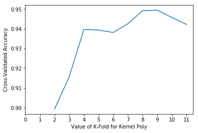

```python
#3. Polynomial

cv = list(range(2,12))
cross_validation_score = []

for i in cv:
    svc=SVC(kernel='poly')
    svc.fit(X_train,y_train)
    y_pred=svc.predict(X_test)
    scores = cross_val_score(svc, X, y, cv=i, scoring='accuracy')
    print('Mean Accuracy Kernel RBF and Cross Validation:')
    print(scores.mean())
    cross_validation_score.append(scores.mean())

plt.plot(cv,cross_validation_score)
plt.xticks(np.arange(0,12,1))
plt.xlabel('Value of K-Fold for Kernel Poly')
plt.ylabel('Cross-Validated Accuracy')

# We take the mean of the value for each different number of cross validation
```

To be conversvative and be aware not being overfitting, we select 7 as the perfect number of CV

# RUNNING SVM | Defining Main Parameters for each Kernel

Once we have the best number of Cros Validation number in order to avoid overfitting or underfitting. Now we need to define for each kernel the main parameters in order to find out the range in which the work better.

1. RBF: Adjusting Gamma
2. Linear: Adjusting C
3. Polynomial: Adjusting Degree

```
[0.8836734296073113, 0.9539714408238051, 0.9703506407436079, 0.9633960246606926, 0.877878612362648, 0.6286235011723297, 0.5]
```

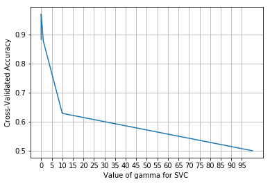

```python
# 1. RBF: Adjusting Gamma

#Gamma parameter is the inverse of the standard deviation of the RBF kernel (Gaussian function),
#which is used as similarity measure between two points. Intuitively, a small gamma value define a Gaussian function with a large variance. In this case, two points can be considered similar even if are far from each other. In the other hand, a large gamma value means define a Gaussian
#function with a small variance and in this case, two points are considered similar just if they are
#close to each other

gamma_range=[0.0001,0.001,0.01,0.1,1,10,100]
acc_score=[]
for g in gamma_range:
    svc = SVC(kernel='rbf', gamma=g)
    scores = cross_val_score(svc, X, y, cv=7, scoring='accuracy')
    acc_score.append(scores.mean())
print(acc_score)

plt.plot(gamma_range,acc_score)
plt.xlabel('Value of gamma for SVC ')
plt.xticks(np.arange(0.0001,100,5))
plt.ylabel('Cross-Validated Accuracy')
plt.grid(b=True)
# Here we can see that for gamma 1 and 100 the model is performing poorly. For this reason, let's go more into detail
```

```
[0.8878114799777087, 0.9552463975798107, 0.9681514210652018, 0.9630960910755512]
```

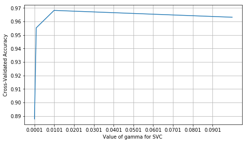

```python
gamma_range=[0.0001,0.001,0.01,0.1]
acc_score=[]
for g in gamma_range:
    svc = SVC(kernel='rbf', gamma=g)
    scores = cross_val_score(svc, X, y, cv=10, scoring='accuracy')
    acc_score.append(scores.mean())
print(acc_score)

# plot the value of C for SVM (x-axis) versus the cross-validated accuracy (y-axis)
plt.rcParams["figure.figsize"] = [8,4.5]
plt.plot(gamma_range,acc_score)
plt.xticks(np.arange(0.0001,0.1,0.01))
plt.xlabel('Value of gamma for SVC ')
plt.ylabel('Cross-Validated Accuracy')
plt.grid(b=True)


##The score increases steadily and raches its peak at 0.01 and then decreases till gamma=1.Thus Gamma should be around 0.01.
#Although we could go further, we are going to stop here and define gamma in a range close to 0.1
#
#
```

```
[0.9675131016891572, 0.9678277649994153, 0.9678291573149475, 0.9678291573149475, 0.9675131016891572, 0.9675131016891572, 0.9675131016891572, 0.9675131016891572, 0.9675131016891572]
```

```
Text(0,0.5,'Cross-Validated Accuracy')
```

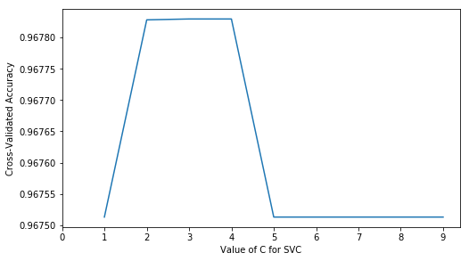

```python
#2. Linear: Adjusting C

#The C parameter tells the SVM optimization how much you want to avoid misclassifying each training example.
#For large values of C, the optimization will choose a smaller-margin hyperplane if that hyperplane does
#a better job of getting all the training points classified correctly. Conversely, a very small value of
#C will cause the optimizer to look for a larger-margin separating hyperplane, even if that hyperplane misclassifies more points.

#Thus for a very large values we can cause overfitting of the model and for a very small
#value of C we can cause underfitting.Thus the value of C must be chosen
#in such a manner that it generalised the unseen data well



C_range=list(range(1,10))
acc_score=[]
for c in C_range:
    svc = SVC(kernel='linear', C=c)
    scores = cross_val_score(svc, X, y, cv=7, scoring='accuracy')
    acc_score.append(scores.mean())
print(acc_score)

plt.plot(C_range,acc_score)
plt.xticks(np.arange(0,10,1))
plt.xlabel('Value of C for SVC')
plt.ylabel('Cross-Validated Accuracy')

# There is a peak between 0.1 and 5 so we need to check more in detail
```

```
[0.9700481649550194, 0.9691007881538095, 0.9690987978664118, 0.9690987978664118, 0.9694132632752168, 0.9694132632752168, 0.9697277286840219, 0.9694112729878194, 0.9690968075790144, 0.9694132632752168, 0.9694132632752168, 0.9694132632752168, 0.9694132632752168, 0.9687823421702095, 0.9690987978664118,…
```

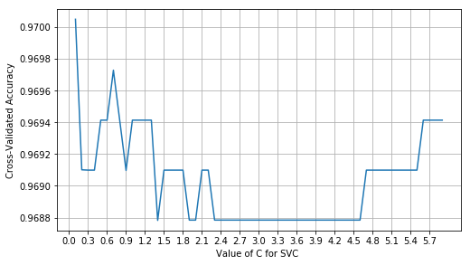

```python
C_range=list(np.arange(0.1,6,0.1))
acc_score=[]
for c in C_range:
    svc = SVC(kernel='linear', C=c)
    scores = cross_val_score(svc, X, y, cv=10, scoring='accuracy')
    acc_score.append(scores.mean())
print(acc_score)

plt.plot(C_range,acc_score)
plt.xticks(np.arange(0.0,6,0.3))
plt.xlabel('Value of C for SVC ')
plt.ylabel('Cross-Validated Accuracy')
plt.grid(b=True)


#The value of C would close to 0.1 since after that the line drops
```

```
[0.8481707758539071, 0.9425725535623786, 0.8273793280128316, 0.8649440010692983, 0.7674150826756964]
3.632049322128296
```

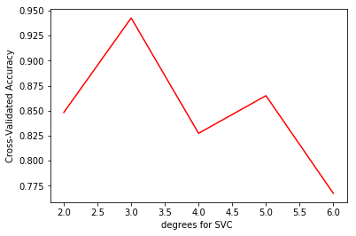

```python
#3. Polynomial

# The degree refers to the number of dimensions

start = time.time()

degree=[2,3,4,5,6]
acc_score=[]
for d in degree:
    svc = SVC(kernel='poly', degree=d)
    scores = cross_val_score(svc, X, y, cv=7, scoring='accuracy')
    acc_score.append(scores.mean())
print(acc_score)

# plot the value of C for SVM (x-axis) versus the cross-validated accuracy (y-axis)
plt.plot(degree,acc_score,color='r')
plt.xlabel('degrees for SVC ')
plt.ylabel('Cross-Validated Accuracy')

end = time.time()
print(end - start)
#It is clearly show that we will play with a 3 degree range
```

# SEARCHING FOR THE BEST KERNEL WITH THE BEST PARAMETERS

```python
svm_model= SVC()


tuned_parameters = {
 'C': (np.arange(0.1,1,0.1)) , 'kernel': ['linear'],
 'C': (np.arange(0.1,1,0.1)) , 'gamma': np.arange(0.05,0.15,0.01), 'kernel': ['rbf'],
 'degree': [2,3,4] ,'gamma':np.arange(0.03,0.7,0.1), 'C':(np.arange(0.1,1,0.1)) , 'kernel':['poly']}

model_svm = GridSearchCV(svm_model, tuned_parameters,cv=7,scoring='accuracy')


model_svm.fit(X_train, y_train)
print(model_svm.best_score_)
print(model_svm.best_params_)
y_pred= model_svm.predict(X_test)
print(metrics.accuracy_score(y_pred,y_test))
```

```
0.970681100586378
{'C': 0.9, 'degree': 3, 'gamma': 0.13, 'kernel': 'poly'}
0.9705573080967402
```

```python
# This would be the grid of all models that are run.

print(model_svm.grid_scores_)
```

[output not shown]

# CHECKING THE PERFORMANCE

A. Confusion Matrix

```python
confusion_matrix=metrics.confusion_matrix(y_test,y_pred)
confusion_matrix

# It is interesting to see that in the confusion matrix there is the same number of fails for male or female.
# This is linked to the idea that the dataset is homogenously split. If we check the SVM run with default parameters we
# see there is a descompensation in this matter.
```

```
array([[443,  14],
       [ 14, 480]])
```

```python
auc_roc=metrics.roc_auc_score(y_test,y_pred)
```

Although we do not manage to get the 0.98 accuracy of the model at the begninning (before cross validation) now we can be sure that we are not overfitting our model and at the same time we are providing the best parameter configuration after checking a range of values for each of them.

# OPTIMISATION | Apply PCA before SVM

```python
pca = PCA(0.95)

#Notice the code below has .95 for the number of components parameter.
#It means that scikit-learn choose the minimum number of principal components
#such that 95% of the variance is retained.

pca.fit(X_train)
X_train= pca.transform(X_train)
X_test= pca.transform(X_test)
pca.n_components_

# Finally we will have 10 components, so we have reduce the dimensionality to the half.
```

```
10
```

```python
# We apply the selection kernel again.


tuned_parameters = {
 'C': (np.arange(0.1,1,0.1)) , 'kernel': ['linear'],
 'C': (np.arange(0.1,1,0.1)) , 'gamma': np.arange(0.05,0.15,0.01), 'kernel': ['rbf'],
 'degree': [2,3,4] ,'gamma':np.arange(0.03,0.7,0.1), 'C':(np.arange(0.1,1,0.1)) , 'kernel':['poly']}

model_svm = GridSearchCV(svm_model, tuned_parameters,cv=7,scoring='accuracy')


model_svm.fit(X_train, y_train)
print(model_svm.best_score_)
print(model_svm.best_params_)
y_pred= model_svm.predict(X_test)
print("Model accuracy= "+ str(metrics.accuracy_score(y_pred,y_test)))
```

```
0.968425800631484
{'C': 0.8, 'degree': 3, 'gamma': 0.23, 'kernel': 'poly'}
Model accuracy= 0.9663512092534174
```

# CHECKING THE PERFORMANCE | PCA + SVM

A. Confusion Matrix

B. ROC and AUC

```python
confusion_matrix=metrics.confusion_matrix(y_test,y_pred)
confusion_matrix

# It is interesting to see that in the confusion matrix there is the same number of fails for male or female.
# This is linked to the idea that the dataset is homogenously split. If we check the SVM run with default parameters we
# see there is a descompensation in this matter.
```

```
array([[441,  16],
       [ 16, 478]])
```

```python
auc_roc=metrics.roc_auc_score(y_test,y_pred)
```

```
Text(0.5,0,'False Positive Rate')
```

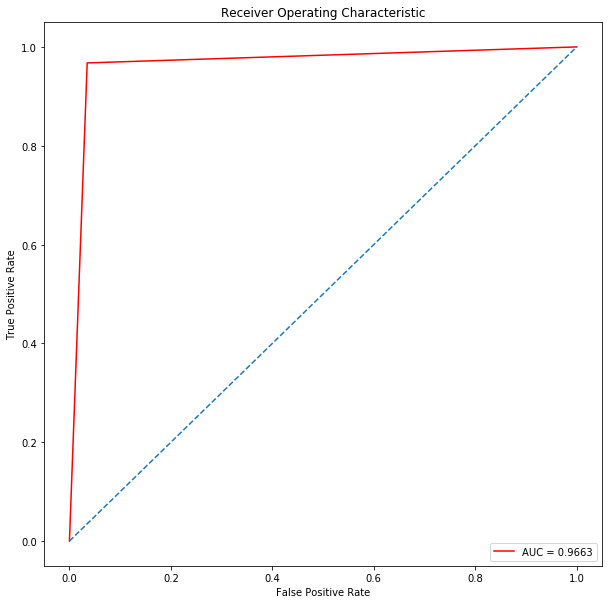

```python
false_positive_rate, true_positive_rate, thresholds = roc_curve(y_test, y_pred)
roc_auc = auc(false_positive_rate, true_positive_rate)

plt.figure(figsize=(10,10))
plt.title('Receiver Operating Characteristic')
plt.plot(false_positive_rate,true_positive_rate, color='red',label = 'AUC = %0.4f' % roc_auc)
plt.legend(loc = 'lower right')
plt.plot([0, 1], [0, 1],linestyle='--')
plt.axis('tight')
plt.ylabel('True Positive Rate')
plt.xlabel('False Positive Rate')
```

# CONCLUSIONS

NOTA IMPORTANTE

When I calculated on anaconda / python (a stable enviroment and with the power of a Macbook Pro late 2018 )

SVM # SEARCHING FOR THE BEST KERNEL WITH THE BEST PARAMETERS performns in = 106.81702089309692 seconds

PCA + SVM # SEARCHING FOR THE BEST KERNEL WITH THE BEST PARAMETERS performns in = 78.79046082496643 seconds

This means a reduction of the 30% of the time in just one cell.

References:

Voice Based Gender Detection Anchita Goel Indraprastha Institute of Information Technology Delhi https://sarthakahuja.org/public/docs/report_he_or_she.pdf

TRABAJO FIN DE GRADO SUPPORT VECTOR REGRESSION: PROPIEDADES Y APLICACIONES Realizado por: Juan José Martín Guareño Supervisado por: Dr. Rafael Blanquero Bravo y Dr. Emilio Carrizosa Priego FACULTAD DE MATEMÁTICAS DEPARTAMENTO DE ESTADÍSTICA E INVESTIGACIÓN OPERATIVA